# Latent interactions (moderation) in SEM

From observed regression to PI and LMS in R

Tommaso Feraco

## Today

1. Quick SEM/CFA refresher
2. Observed moderation (simulation) with `lm()` and `lavaan`
3. Why “SEM interactions” (latent interactions) are worth the trouble
4. The main technical difficulties (what breaks, why)
5. Options in practice: PI (dblcent) vs LMS/QML (and what to report)

**Tip**

**Measurement-first reminder:** validate the *measurement model* (CFA) before fitting any interaction…or anything in general!

## Learning objectives

By the end of this deck, you can:

- Simulate a simple moderation with latent variables and observed indicators
- Fit observed moderation via `lm()` and via `lavaan::sem()`
- Explain *why* latent interactions are harder than observed ones
- Fit a latent interaction in `modsem` using:
  - product-indicator (PI) approach: `method = "dblcent"`
  - distribution-analytic approach: `method = "lms"` (and know what “qml” is)
- Probe and visualize the interaction (simple slopes, JN, surface)

## Minimal SEM/CFA refresher

**Core idea**

- Latent construct $(\xi)$ is measured by indicators $(x_1, x_2, x_3)$

$$x_i = \lambda_i\,\xi + \delta_i$$

- **CFA**: estimate loadings $(\lambda)$ and measurement error $(\delta)$
- **SEM**: add structural regressions among latent variables

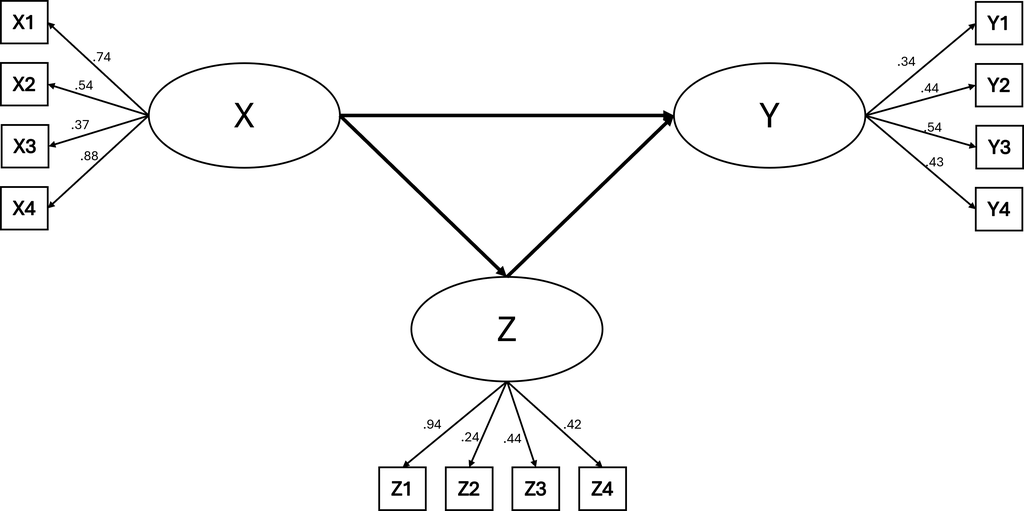

## Why measurement modeling matters for moderation

Observed moderation uses *measured variables*.

If the constructs are measured with error (and they always are):

- Main effects attenuate
- Interaction effects attenuate **even more**

**Intuition:** the product term is “signal × signal” but also “error × signal” and “error × error”.

**Warning**

Less precise measurements (higher error) decreases power [NO PUBLICATIONS!]! For interactions, power is already usually very low

## Simulation setup

We’ll simulate:

- Outcome (latent): **achievement** (Y)
- Predictor (latent): **intelligence** (X)
- Moderator (latent): **anxiety** (Z)

Structural part (prediction of the outcome):

$$Y = \beta_X X + \beta_Z Z + \beta_{XZ}(X\cdot Z) + \varepsilon$$

Then we create **3 indicators per construct**.

## Simulate latent variables

```r
set.seed(123)

# ----------------------
# Design choices
# ----------------------
N <- 500

# Structural effects (interpretable):
# - intelligence helps achievement
# - anxiety hurts achievement
# - anxiety reduces the benefit of intelligence (negative interaction)
b_X  <-  0.40
b_Z  <- -0.30
b_XZ <- -0.20

# Correlation between X and Z (optional)
rho_XZ <- -0.20

# Latent predictors (bivariate normal)
# We'll construct Z with the desired correlation with X
X <- rnorm(N, mean = 0, sd = 1)
E_Z <- rnorm(N, mean = 0, sd = 1)
Z <- rho_XZ * X + sqrt(1 - rho_XZ^2) * E_Z

XZ <- X * Z

# Latent outcome
lin <- b_X * X + b_Z * Z + b_XZ * XZ
var_lin <- var(lin)

# choose residual variance so that Var(Y) ~ 1
var_e <- max(1e-6, 1 - var_lin)
Y <- lin + rnorm(N, mean = 0, sd = sqrt(var_e))

c(var_X = var(X), var_Z = var(Z), var_XZ = var(XZ), var_Y = var(Y))
```

```
    var_X     var_Z    var_XZ     var_Y
0.9462803 1.0389162 0.9744937 1.0134686
```

## Create observed indicators

We’ll use loadings $(\lambda)$ around .70–.80 (VERY GOOD ITEMS!)

```r
# Loadings (can be different per construct if you want)
lambda_X <- c(.80, .70, .75)
lambda_Z <- c(.80, .70, .75)
lambda_Y <- c(.80, .70, .75)
# For standardized latent variables, choose residual variances so items are ~standardized
# Var(item) ≈ lambda^2 * Var(latent) + theta; with Var(latent)=1, set theta = 1 - lambda^2
theta_X <- 1 - lambda_X^2
theta_Z <- 1 - lambda_Z^2
theta_Y <- 1 - lambda_Y^2
# Intelligence indicators (explicit; no helper function)
int1 <- lambda_X[1] * X + rnorm(N, 0, sqrt(theta_X[1]))
int2 <- lambda_X[2] * X + rnorm(N, 0, sqrt(theta_X[2]))
int3 <- lambda_X[3] * X + rnorm(N, 0, sqrt(theta_X[3]))
# Anxiety indicators
anx1 <- lambda_Z[1] * Z + rnorm(N, 0, sqrt(theta_Z[1]))
anx2 <- lambda_Z[2] * Z + rnorm(N, 0, sqrt(theta_Z[2]))
anx3 <- lambda_Z[3] * Z + rnorm(N, 0, sqrt(theta_Z[3]))
# Achievement indicators
ach1 <- lambda_Y[1] * Y + rnorm(N, 0, sqrt(theta_Y[1]))
ach2 <- lambda_Y[2] * Y + rnorm(N, 0, sqrt(theta_Y[2]))
ach3 <- lambda_Y[3] * Y + rnorm(N, 0, sqrt(theta_Y[3]))

# Data frame of observed items
dat <- data.frame(
  int1 = int1, int2 = int2, int3 = int3,
  anx1 = anx1, anx2 = anx2, anx3 = anx3,
  ach1 = ach1, ach2 = ach2, ach3 = ach3
)
# head(dat)
```

## Observed totals (sum/mean scores)

This is what many researchers do (sometimes without realizing the cost for interactions and their meaning from a latent perspective).

```r
dat$intelligence_total <- rowMeans(dat[, c("int1","int2","int3")])
dat$anxiety_total      <- rowMeans(dat[, c("anx1","anx2","anx3")])
dat$achievement_total  <- rowMeans(dat[, c("ach1","ach2","ach3")])

# Center for interpretability: Z = 0 means "average anxiety"
dat$int_c <- as.numeric(scale(dat$intelligence_total, scale = FALSE))
dat$anx_c <- as.numeric(scale(dat$anxiety_total,      scale = FALSE))

dat$int_x_anx <- dat$int_c * dat$anx_c

summary(dat[, c("intelligence_total","anxiety_total","achievement_total")])
```

```
 intelligence_total anxiety_total        achievement_total
 Min.   :-2.43141   Min.   :-2.6564607   Min.   :-2.46318
 1st Qu.:-0.46922   1st Qu.:-0.5218372   1st Qu.:-0.53039
 Median : 0.06996   Median :-0.0005894   Median : 0.05928
 Mean   : 0.02769   Mean   :-0.0207312   Mean   : 0.07591
 3rd Qu.: 0.54621   3rd Qu.: 0.5289116   3rd Qu.: 0.62722
 Max.   : 2.47346   Max.   : 2.3890175   Max.   : 2.84914
```

**Warning**

Sum scores require many assumptions that we rarely test (e.g., equal loadings)

## Observed moderation with `lm()`

```r
fit_lm <- lm(achievement_total ~ int_c * anx_c , data = dat)
#            achievement_total ~ int_c + anx_c + int_x_anx
coef(summary(fit_lm))
```

```
               Estimate Std. Error   t value     Pr(>|t|)
(Intercept)  0.04925102 0.03396313  1.450132 1.476537e-01
int_c        0.38302542 0.04295836  8.916203 9.268394e-18
anx_c       -0.21927094 0.04007868 -5.471012 7.110258e-08
int_c:anx_c -0.26707651 0.05344051 -4.997641 8.059989e-07
```

Interpretation:

- `int_c`: effect of intelligence when **anxiety is average** (0 after centering)
- `anx_c`: effect of anxiety when intelligence is average
- `int_x_anx`: *moderation* (how the effect of intelligence changes as anxiety increases)

## Observed moderation with `lavaan::sem()`

Same regression, but estimated with SEM syntax.

```r
library(lavaan)

mod_obs <- '
  achievement_total ~ int_c + anx_c + int_c:anx_c
# achievement_total ~ int_c + anx_c + int_x_anx
'

fit_obs <- sem(mod_obs, data = dat, meanstructure = TRUE)

pe <- parameterEstimates(fit_obs, standardized = TRUE)
pe[pe$op == "~", c("lhs","op","rhs","est","se","pvalue","std.all")]
```

```
                lhs op         rhs    est    se pvalue std.all
1 achievement_total  ~       int_c  0.383 0.043      0   0.350
2 achievement_total  ~       anx_c -0.219 0.040      0  -0.216
3 achievement_total  ~ int_c:anx_c -0.267 0.053      0  -0.196
```

**Important**

We can write the interaction part in two ways because the interaction term is actually a new variable given by the multiplication of the two predictors.

## Observed interaction is not “wrong”, but…

Observed moderation can be fine when:

- variables are measured with high reliability
- you’re comfortable treating totals as error-free
- your goal is prediction, not latent construct inference

But in psychological measurement:

- reliability is often moderate
- measurement error is non-trivial
- interaction effects are small → easily attenuated
- measures are bound and not really continuous

# SEM interactions and issues

## SEM moderation = latent interaction

We want:

$$\eta_Y = \beta_X\,\xi_X + \beta_Z\,\xi_Z + \beta_{XZ}(\xi_X\xi_Z) + \zeta$$

**Problem**: $(\xi_X\xi_Z)$ is not observed.

Two main families of solutions:

1. **Product indicators (PI):** build observed products (e.g., $(x_i z_j)$) and model them as indicators of a latent interaction factor.
2. **LMS/QML (distribution-analytic):** estimate the interaction directly in the likelihood (no product indicators), but standard global fit indices typically disappear (we move away from covariance estimation).

**Tip**

`modsem` has multiple approaches available https://modsem.org/articles/methods.html

## The main technical issues

1. **Nonlinearity**: interaction makes the model nonlinear
2. **Non-normality**: product of normals is not normal
3. **Fit logic changes**: especially with LMS (no classical $(\chi^2)$, CFI, RMSEA for the interaction model)

Everything else is a consequence: identification, centering confusion, computational burden, interpretation…but also better estimates, correct modelling…

## Difficulty 1 — The product is latent (not observed)

In regression: compute $(XZ)$.

In SEM:

- X and Z are latent
- you only have indicators
- product indicators contain extra error cross-terms

**Tip**

Product indicator means that we are multiplying each item of a scale with all other items, thus creating many other ‘*observed*’ variables, which will form a ‘*new*’ latent interaction measure.

## Difficulty 2 — Non-normality of the product

Even if $(X)$ and $(Z)$ are normal, $(XZ)$ is not.

```r
par(mfrow = c(1, 2))
hist(X,  main = "Latent X (normal)")
hist(XZ, main = "Latent X*Z (non-normal)")
```

```r
par(mfrow = c(1, 1))
```

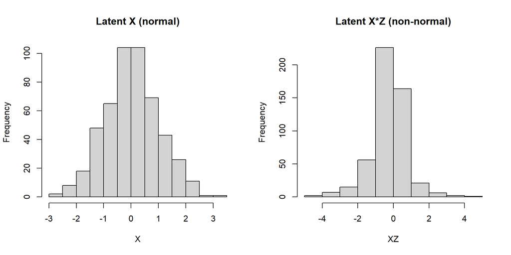

Implication: classical normal-theory SEs / tests can misbehave, especially in small N.

## Difficulty 3 — Identification + parameter explosion (PI)

If $X$ has $(p)$ indicators and Z has $(q)$ indicators:

- “all-pairs” product indicators: $(pq)$
- many shared components → correlated residuals are plausible
- too many free covariances can break identification

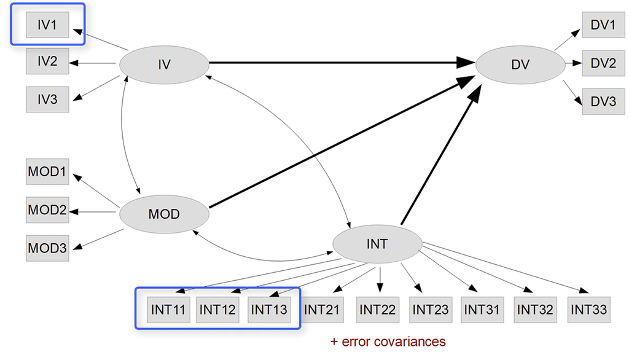

**Warning**

PI is transparent but can become a *big* model fast.

## Difficulty 4 — Fit indices disappear (LMS)

With LMS/QML you typically **cannot** report classical SEM global fit indices for the **interaction model**.

So evaluation becomes:

1. Fit baseline model (no interaction): report CFI/TLI/RMSEA/SRMR there
2. Add interaction: compare baseline vs interaction using **log-likelihood difference test** (or AIC/BIC)

This is a conceptual shift: fit ≠ truth, and sometimes fit ≠ available.

**Warning**

With PI fit indices remain, but non-normality issues too. Consider using robust fit indices.

**Tip**

LMS/QML are estimated with distribution-analytic likelihood methods (integration / EM-type routines) and the interaction model is not evaluated using the standard “fit covariance matrix $𝑆$ with $Σ(θ)$” machinery.

## Difficulty 5 — Interpretation is conditional (probing)

The simple slope of $X$ depends on $Z$:

$$\frac{\partial Y}{\partial X} = \beta_X + \beta_{XZ} Z$$

So there is no single “main effect” of X.

You must probe:

- simple slopes (e.g., Z = -1, 0, +1 SD)
- Johnson–Neyman region
- surface plots

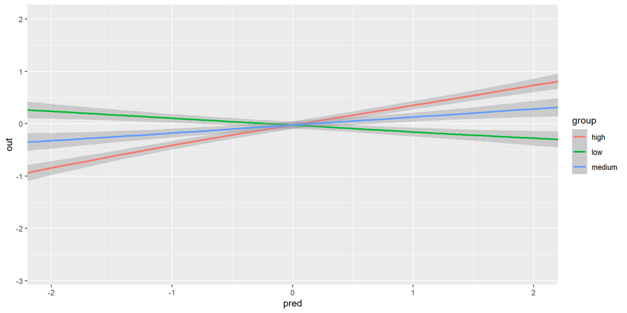

## Difficulty 6 — Centering: interpretation vs estimation

**Interpretation:** $(\beta_X)$ is the effect of X when $(Z=0)$. Centering makes “0” meaningful (often the mean).

**Estimation (PI):** centering indicators/products helps separate lower-order and interaction variance and stabilizes the model.

Rule of thumb:

- PI methods: use **double-mean centering** (e.g., `dblcent`)
- LMS/QML: focus on interpretability (what does Z=0 mean?) and probe slopes

## Difficulty 7 — Computation & power

- interaction effects are typically smaller than main effects
- larger N needed for stable detection
- PI: bigger model → more convergence problems
- LMS/QML: numerical integration / iterative routines → slower, sometimes fragile

**Evaluate:** always report convergence, warnings, and sensitivity checks.

# Solutions?

## Option 0 — “Observed proxies” (baseline)

- totals / sum scores
- factor-score regression

Pros:

- simple and familiar

Cons:

- treats measurement error as absent or “handled” by factor scores
- interaction often attenuates

## Option 1 — Latent interaction via product indicators (PI)

**Idea:** create product indicators and treat them as indicators of a latent interaction factor.

Common centering tricks:

- mean-centering indicators
- **double-mean centering** (default)
- residual centering (advanced; changes meaning)

Pros:

- classic SEM machinery applies (often fit indices available)

Cons:

- parameter heavy
- identification + correlated residual decisions

## Option 2 — Latent Moderated Structural Equations (LMS)

**Idea:** estimate $(XZ)$ in the likelihood (no product indicators).

Pros:

- elegant, avoids product-indicator explosion
- supports **higher-order** interactions

Cons:

- classical global fit indices typically not available for interaction model
- must use baseline fit + LRT / IC

## Now: fit the latent interaction with `modsem`

We fit the same SEM twice:

- **PI dblcent** (`method = "dblcent"`)
- **LMS** (`method = "lms"`) and mention **QML**

NOTE: You need the modsem package installed.

## Latent interaction with PI dblcent

**Baseline SEM (no interaction)**

```r
library(modsem)

model_base <- '
  intelligence =~ int1 + int2 + int3
  anxiety      =~ anx1 + anx2 + anx3
  achievement  =~ ach1 + ach2 + ach3

  achievement ~ intelligence + anxiety
'

fit_base <- modsem(model_base, data = dat)
# summary(fit_base)
```

Evaluate baseline fit (global + local) before adding interaction.

**PI interaction**

```r
model_int <- '
  intelligence =~ int1 + int2 + int3
  anxiety      =~ anx1 + anx2 + anx3
  achievement  =~ ach1 + ach2 + ach3

  achievement ~ intelligence + anxiety +
                intelligence:anxiety
'

fit_dblcent <- modsem(model_int,
        data = dat, method = "dblcent")
# summary(fit_dblcent)
```

Check LRT compared to baseline + convergence, sign/magnitude of interaction path, whether estimates are stable (SEs not exploding)

## Latent interaction with LMS (and QML)

```r
fit_lms <- modsem(model_int, data = dat, method = "lms")
fit_qml <- modsem(model_int, data = dat, method = "qml")

# summary(fit_lms)
# summary(fit_qml)
```

**Evaluate (LMS/QML):**

- baseline model: classical fit indices
- interaction model: compare log-likelihood vs baseline (LRT) and check AIC/BIC

## Plots

```r
p <- plot_interaction(x = "intelligence", z = "anxiety",
                      y = "achievement", vals_z = c(-1, 1),
                      model = fit_lms)
p
```

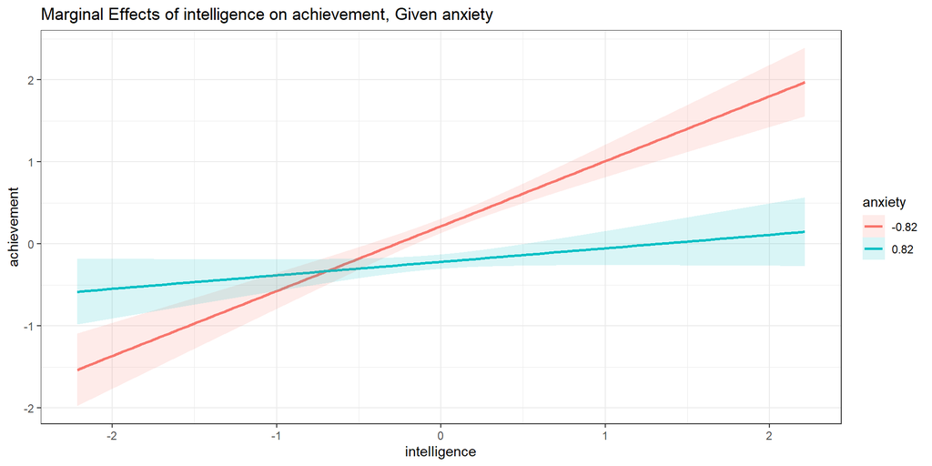

## LMS evaluation: baseline fit + LRT

```r
# pseudo-code: exact methods depend on the object class and available methods

fit_lms <- modsem(model_int, data = dat, method = "lms")
fit_base <- estimate_h0(fit_lms, calc.se = FALSE)

compare_fit(est_h1 = fit_lms, est_h0 = fit_base)
```

```
$D
[1] 23.78654

$df
[1] 1

$p
[1] 1.076325e-06

$diff.loglik
[1] 11.89327
```

**Important**

**Teaching point:** don’t “evaluate fit” of the interaction model using missing CFI/RMSEA. Use baseline fit (this should be good) + LRT logic.

## Summary

Regression paths to achievement across models (Estimate (SE)).

| model | intelligence | anxiety | intelligence:anxiety |
| --- | --- | --- | --- |
| Observed sum-scores (lavaan) | 0.383 (0.043) | -0.219 (0.040) | -0.267 (0.053) |
| Baseline (no interaction) | 0.505 (NA) | -0.292 (NA) | NA |
| PI dblcent | 0.481 (0.065) | -0.247 (0.054) | -0.488 (0.119) |
| LMS | 0.478 (0.066) | -0.264 (0.054) | -0.381 (0.082) |
| QML | 0.488 (0.067) | -0.262 (0.054) | -0.433 (0.087) |

## Who’s best? A simple simulation

```r
# simulation parameters
R <- 500; N <- 400; rho_xz <- 0.30
beta_x  <- 0.30; beta_z  <- 0.30
beta_xz <- 0.20  # <-- ground
lambda_int <- c(.80, .70, .75);
lambda_anx <- c(.80, .70, .75)
lambda_ach <- c(.80, .70, .75)
```

Interaction estimate across methods

| model | mean_est | sd_est | bias | rmse | mean_se | power_p |
| --- | --- | --- | --- | --- | --- | --- |
| Latent LMS | 0.20 | 0.06 | 0.00 | 0.06 | 0.06 | 0.91 |
| Latent PI dblcent | 0.21 | 0.07 | 0.01 | 0.07 | 0.06 | 0.89 |
| Latent QML | 0.20 | 0.06 | 0.00 | 0.06 | 0.06 | 0.91 |
| Observed sum-scores (lavaan) | 0.15 | 0.05 | -0.05 | 0.07 | 0.04 | 0.91 |
| Observed sum-scores (lm) | 0.15 | 0.04 | -0.05 | 0.07 | 0.04 | 0.91 |

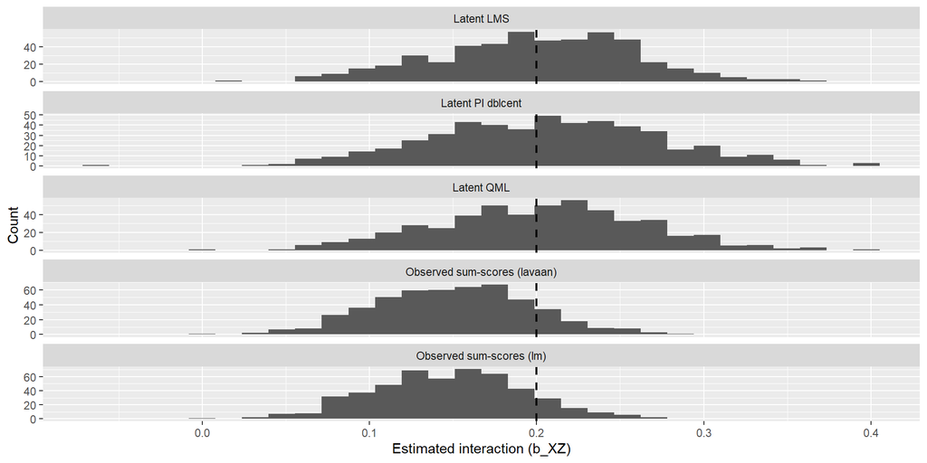

## Probing the interaction (simple slopes, JN, surface)

```r
# Probing works directly on modsem fits

# simple_slopes(model = fit_lms, x = "intelligence", z = "anxiety", y = "achievement")
# plot_surface(model = fit_lms, x = "intelligence", z = "anxiety", y = "achievement")

plot_jn(model = fit_lms, x = "intelligence", z = "anxiety", y = "achievement")
```

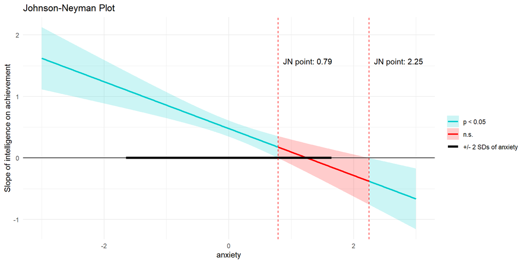

## “Under the hood”: product indicators with semTools + lavaan

```r
library(semTools)

# matched-pair products, double-mean centered
# (x1*z1, x2*z2, x3*z3)
dat_pi <- indProd(
  data = dat,
  var1 = c("int1","int2","int3"),
  var2 = c("anx1","anx2","anx3"),
  match = TRUE,
  meanC = TRUE,
  doubleMC = TRUE
)

prod_names <- grep("^int[1-3].*anx[1-3]$", names(dat_pi), value = TRUE)

model_pi <- paste0('
  intelligence =~ int1 + int2 + int3
  anxiety      =~ anx1 + anx2 + anx3
  achievement  =~ ach1 + ach2 + ach3

  intxn =~ ', paste(prod_names, collapse = " + "), '

  achievement ~ intelligence + anxiety + intxn
')

fit_pi <- lavaan::sem(model_pi, data = dat_pi, meanstructure = TRUE)
summary(fit_pi, fit.measures = TRUE, standardized = TRUE)
```

## Reporting checklist (minimal)

1. **Measurement (baseline):** CFA/SEM fit (CFI/TLI/RMSEA/SRMR) + key loadings
2. **Interaction method:** PI (dblcent) or LMS/QML (and why)
3. **Evaluation:**
- PI: report SEM fit indices (if available) + local diagnostics
- LMS/QML: baseline fit indices + LRT (ΔlogLik) or AIC/BIC
4. **Effect reporting:** $(\hat\beta_{XZ})$, SE/CI, probing results (simple slopes / JN)
5. **Transparency:** centering decisions and what “0” means for the moderator

# Interactions as MG-CFA

## Group comparisons (classic mg-cfa)

When the interaction term is not a continuous [latent] variable, we can run interactions using MG-CFA (slides [here](https://feracotommaso.github.io/SEM-phd-course/slides/07_invariance_mgcfa_partialinvariance.html##/structural-invariance))

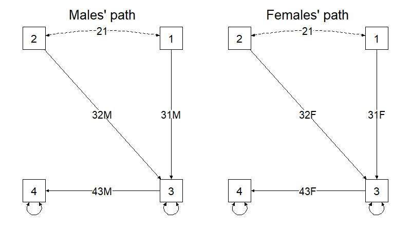

```r
m.med=sem(model,data,group="sex",
          group.equal=c("loadings","intercepts",
                        "regressions" # <---------- #
                        )
          )
```

## Group comparisons (handmade mg-cfa)

```r
model_equal <- '
# measurement
intelligence =~ int1 + int2 + int3
achievement  =~ ach1 + ach2 + ach3

# structural path
achievement ~ c(b,b)*intelligence
'
fit_equal <- sem(model_equal, data = dat,
                 group = "sex")
```

```r
model_free <- '
# measurement
intelligence =~ int1 + int2 + int3
achievement  =~ ach1 + ach2 + ach3

# structural path
achievement ~ c(b_m, b_f)*intelligence
'
fit_free <- sem(model_free, data = dat,
                group = "sex")
```

```r
anova(fit_equal, fit_free)
```

```
Chi-Squared Difference Test

          Df    AIC    BIC  Chisq Chisq diff RMSEA Df diff Pr(>Chisq)
fit_free  16 7540.7 7700.9 27.024
fit_equal 17 7539.6 7695.5 27.875    0.85081     0       1     0.3563
```

## Take-home: 3 things

1. Latent interactions are hard because the product term introduces **nonlinearity + non-normality**.
2. **PI dblcent** is transparent (and often provides classic fit machinery) but can be heavy/fragile.
3. **LMS/QML** are elegant for estimation, but they force a new evaluation mindset: **baseline fit + LRT**, plus probing for interpretation.

## Further reading / self-study links

- `modsem` documentation and vignettes (https://modsem.org/articles/modsem.html)
- `modsem` R package documentation (product indicator methods; LMS/QML; probing functions)
- semTools documentation for `indProd()`
- Aiken, L. S., & West, S. G. (1991). *Multiple regression: Testing and interpreting interactions.*

## References

Jorgensen, T. D., Pornprasertmanit, S., Schoemann, A. M., & Rosseel, Y. (2022). *semTools: Useful tools for structural equation modeling*. https://CRAN.R-project.org/package=semTools

Rosseel, Y. (2012). *lavaan: an R package for structural equation modeling and more Version 0.5-12 (BETA)*. 37.

Slupphaug, K. S., Mehmetoglu, M., & Mittner, M. (2025). Modsem: An r package for estimating latent interactions and quadratic effects. *Structural Equation Modeling: A Multidisciplinary Journal*, *32*(4), 717–729. https://doi.org/10.1080/10705511.2024.2417409

Solem Slupphaug, K. (n.d.). *modsem: Latent Interaction (and Moderation) Analysis in Structural Equation Models (SEM)*. https://doi.org/10.32614/CRAN.package.modsem